# Data Mining II - Practical Assignment: Restaurant Recommendation

Ariadne Fernandes, Guilherme Cardoso, Rodrigo Barros

# 1 Project Description

The aim of this practical assignment is to compare the performance of different recommendation strategies on a data set obtained from ChefMoz, a recommender system prototype for the recommendation of restaurants. This system is currently inactive and in order to allow the study and development of different recommender systems, part of its restaurant and consumer data has been uploaded to UCI repository and it was downloaded to be the explored dataset. The task is to generate a top N list of restaurants according to the consumer preferences.

# 2 Project Setup

## 2.1 Software and Tools

All the data was imported, preprocessed and analysed on R Studio, elaborating next a rMarkdown file to create the report.

## 2.2 Libraries Import

Packages as “dplyr”, “plyr” , “tidyr” and “tibble” were used to manipulate the data and packages as “ggplot”, “ggmap,”grid“,”ggdendro" and “gridExtra” were used to generate and layout the display of plots.

```r
library(ggplot2)
library(lubridate)
library(dplyr)
library(plyr)
library(Hmisc)
library(tidyr)
library(purrr)
library(ggdendro)
library(ggmap)
library("recommenderlab")
library(tibble)
library(gridExtra)
library(grid)

set.seed(2016)
```

## 2.3 Data Import

```r
## Restaurant Data Import

chefmozaccepts <- read.csv(paste(project_path,"RCdata/chefmozaccepts.csv",sep=""))
chefmozcuisine <- read.csv(paste(project_path,"RCdata/chefmozcuisine.csv",sep=""))
chefmozhours4 <- read.csv(paste(project_path,"RCdata/chefmozhours4.csv",sep=""))
chefmozparking <- read.csv(paste(project_path,"RCdata/chefmozparking.csv",sep=""))
geoplaces2 <- read.csv(paste(project_path,"RCdata/geoplaces2.csv",sep=""))

## User Data Import

userprofile <- read.csv(paste(project_path,"RCdata/userprofile.csv",sep=""))
usercuisine = read.csv(paste(project_path,"RCdata/usercuisine.csv",sep=""))
userRat = read.csv(paste(project_path,"RCdata/rating_final.csv",sep=""))
userpayment = read.csv(paste(project_path,"RCdata/userpayment.csv",sep=""))
```

# 3 Preliminary Exploratory Data Analysis of the Available Data.

The analysis was made in all CSV files, that contains information about the users profiles, the rating given by then and also the restaurants categories and characteristics, using the aid of plotting to better visualize the data and the context of the problem.

## 3.1 Restaurants DATA

### 3.1.1 chefmozaccepts.csv

#### 3.1.1.1 Main information

This datset presented 1314 instaces with 2 attribustes: placeID and Rpayment. The Rpayment variable presents the paying methods accepted by each restaurants.

When analyzing the chefmozaccepts.csv file, it was possible to see that the “visa” way of payment was registered in two ways: “VISA” and “visa”, so it was necessary to combine them to represent the same data.

```r
chefmozaccepts$Rpayment[chefmozaccepts$Rpayment == 'Visa'] <- "VISA"
```

```r
g2 <- ggplot(chefmozaccepts, aes(Rpayment))+geom_histogram( stat="count") +
  theme(axis.text.x = element_text(angle = 45, hjust = 1)) +
  labs(title="Restaurants x Payment Methods")

g1 <- ggplot( test_credit_card , aes(Rpayment))+geom_histogram( stat="count") +
  theme(axis.text.x = element_text(angle = 45, hjust = 1)) +
  labs(title="Restaurants x Grouped Payment Methods")
```

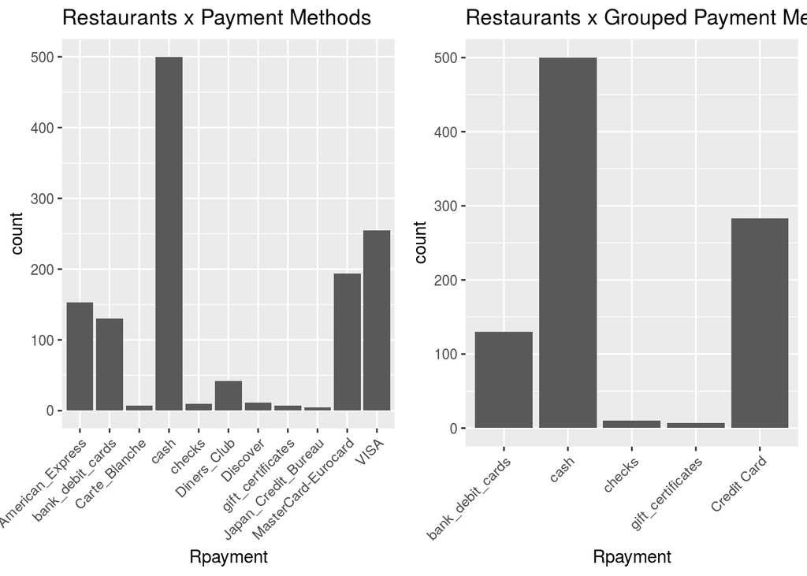

```r
grid.arrange(g2, g1, ncol = 2)
```

#### 3.1.1.2 Overview

- Besides Cash is the most accepted payment method, not all places accept it.
- Between all credit cards options, the most accepted are Visa and Master. The least accepted cards are JCB and Carte Blanche.

After grouping all credit-cards:

- Cash is still the most accepted payment method
- Credit-card is the seconnd followed by Debit cards
- The least accepted are gift vouchers and checks

### 3.1.2 chefmozcuisine.csv

#### 3.1.2.1 Main information

The dataset presented 916 instances with two attributes: placeID and Rcuisine. The Rcuisine variable described the types of cuisine of each restaurant. When analyzing the chefmozcuisine.csv file, it was possible to see how all the restaurantes were categorized, and that there were 59 types of restaurants.

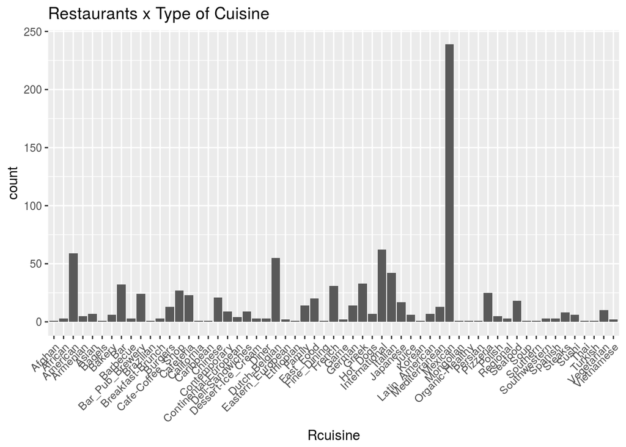

#### 3.1.2.2 Overview

- Most of the restaurants are Mexican cuisine ( considering that the dataset is from mexico restaurants, it makes sense)
- Followed by International cuisine, dutch-bengian ,American and italian
- The least present cuisine are : Afghan, Bagels, Brazilian, California, Caribbean ,Ethiopian, Fine_Dining, Korean, Mongolian ,Organic-Healthy Persian, Soup, Southern, Thai, Turkish , with 1 appearence on the dataset
- Some types of restaurantes could be united in one category, like hotdogs and burguers being ast food, but not all restaurants of this type are also classified as fast food, as it’s shown in the following analysis.

```
##     placeID      Rcuisine
## 126  134976       Mexican
## 127  134976 Mediterranean
## 128  134976       Burgers
## 761  132235      American
## 762  132235       Burgers
```

```
##     placeID Rcuisine
## 177  132962  Burgers
## 178  132962 Hot_Dogs
```

### 3.1.3 chefmozhours4.csv

#### 3.1.3.1 Main information

The dataset presented 2339 instances with three attributes: placeID, hours and days. The hours and days variables describe the days, opening and closing hours for each restaurant. When analyzing the chefmozhours4.csv file, it was possible to see the working hours range of the restaurants, considering week days and weekends. There were also some duplicated data, that was disconsidered.

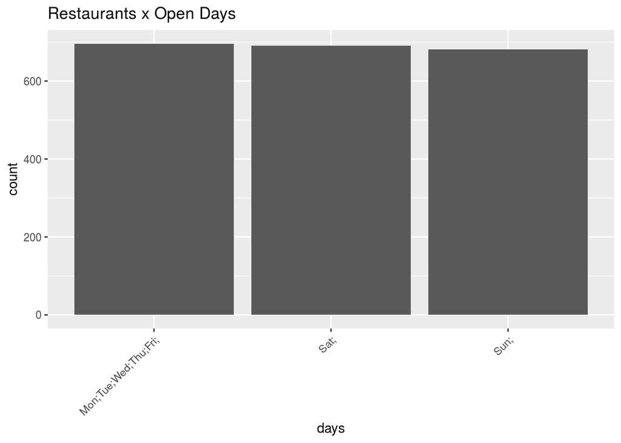

#### 3.1.3.2 Overview

- most of the restaurants are open on Mon;Tue;Wed;Thu;Fri; followed by Sat and Sun

```
## Mon;Tue;Wed;Thu;Fri;                 Sat;                 Sun;
##                  696                  691                  681
```

Some tests were made trying to improve the information visualization.

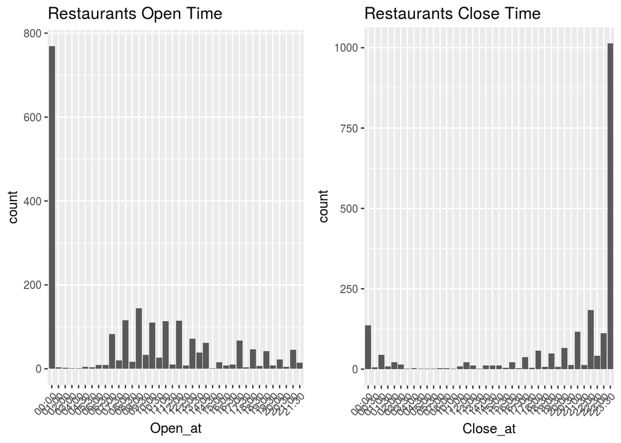

```r
g1 <- ggplot( teste , aes(Open_at))+geom_histogram( stat="count") +
  theme(axis.text.x = element_text(angle = 45, hjust = 1)) +
  labs(title="Restaurants Open Time")


g2 <- ggplot( teste , aes(Close_at))+geom_histogram( stat="count") +
  theme(axis.text.x = element_text(angle = 45, hjust = 1)) +
  labs(title="Restaurants Close Time")
```

#### 3.1.3.3 Overview

- Most of the restaurantes open for lunch
- Most restaurants open at 00:00. this seams like an error for the dataset
- Most of the restaurantes close between 23:30 and 00:00 and that seams reasanable
- These new columns are not reliable based on the formation strategy and data. Time slots are overlaping

### 3.1.4 chefmozparking.csv

#### 3.1.4.1 Main information

This dataset presented 702 instances with 2 attributes: placeID and parking_lot. When analyzing the the dataset, it was possible to see if the restaurants have any parking space and if so, what kind it is.

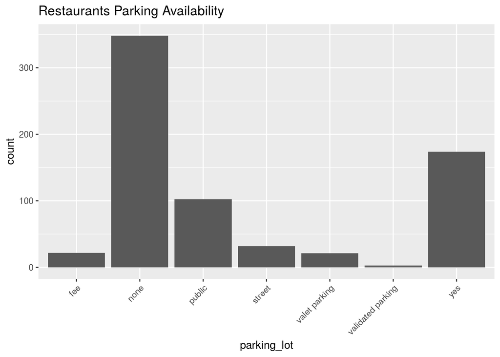

```r
ggplot( chefmozparking , aes(parking_lot))+geom_histogram( stat="count") +
  theme(axis.text.x = element_text(angle = 45, hjust = 1)) +
  labs(title="Restaurants Parking Availability")
```

#### 3.1.4.2 Overview

- It seams that most of the restaurants dont have a parking space
- There is an “yes” in the dataset that is not clear if this means a private parking.
- if you consider that most of the “yes” does not present other type of parking, this probably means a private parking (as shown below)

```r
yes <-chefmozparking$placeID[chefmozparking$parking_lot =="yes"]
count(chefmozparking[chefmozparking$placeID %in% yes,], 'parking_lot')
```

```
##   parking_lot freq
## 1      public    2
## 2      street    1
## 3         yes  174
```

- After analyzing, 174 (25%) restaurants have private parking

### 3.1.5 geoplaces.csv

#### 3.1.5.1 Main information

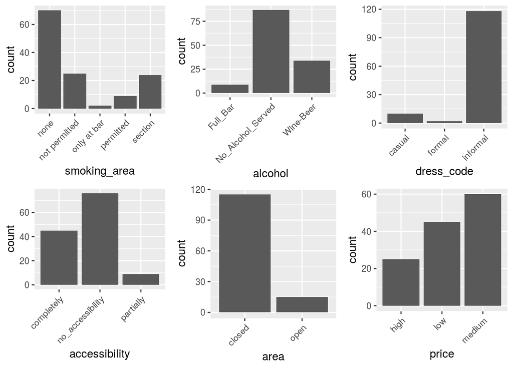

```r
g1 <- ggplot( geoplaces2 , aes(smoking_area))+geom_histogram( stat="count") +
  theme(axis.text.x = element_text(angle = 45, hjust = 1))

g2 <- ggplot( geoplaces2 , aes(alcohol))+geom_histogram( stat="count") +
  theme(axis.text.x = element_text(angle = 45, hjust = 1))

g3 <- ggplot( geoplaces2 , aes(dress_code))+geom_histogram( stat="count") +
  theme(axis.text.x = element_text(angle = 45, hjust = 1))

g4 <- ggplot( geoplaces2 , aes(accessibility))+geom_histogram( stat="count") +
  theme(axis.text.x = element_text(angle = 45, hjust = 1))

g5 <- ggplot( geoplaces2 , aes(area))+geom_histogram( stat="count") +
  theme(axis.text.x = element_text(angle = 45, hjust = 1))

g6 <- ggplot( geoplaces2 , aes(price))+geom_histogram( stat="count") +
  theme(axis.text.x = element_text(angle = 45, hjust = 1))
```

#### 3.1.5.2 Overview

- Most of restaurants do not permit smoking or have a separated area for smoking
- The value “none” can be a missing value for the variable
- The majority of restaurants do not serve alcohol
- The majority of restaurants have informal dress code
- The majority of restaurants don’t have accessibility
- The majority of restaurants have a closed area

It was also checked the location of the restaurants by the latitude and longitude information, and most of them are located in Mexico. That explains why most of rated restaurants are of mexican food.

[figure not shown]

```r
g1 <- ggmap(mxmap2) +
      geom_point(aes(x = geoplaces2$longitud, y = geoplaces2$latitude, size = 1), data = geoplaces2, alpha = .5) +
      labs(title="Restaurant Location")

g2 <- ggmap(mxmap1) +
      geom_point(aes(x = geoplaces2$longitud, y = geoplaces2$latitude, size = 1), data = geoplaces2, alpha = .5) +
      labs(title="Restaurant Location + - Zoom in")
```

## 3.2 Users DATA

### 3.2.1 userprofile.csv

#### 3.2.1.1 Main information

When analyzing the userprofile.csv file, it was possible to see many characteristics of the user, as religion, color, age, drink level, dress code preference, budget, and many others features.

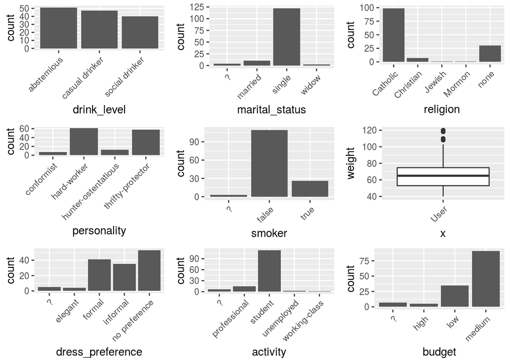

```r
g1 <- ggplot( userprofile , aes(drink_level))+geom_histogram( stat="count") +
  theme(axis.text.x = element_text(angle = 45, hjust = 1))

g2 <- ggplot( userprofile , aes(marital_status))+geom_histogram( stat="count") +
  theme(axis.text.x = element_text(angle = 45, hjust = 1))

g3 <- ggplot( userprofile , aes(religion))+geom_histogram( stat="count") +
  theme(axis.text.x = element_text(angle = 45, hjust = 1))

g4 <- ggplot( userprofile , aes(personality))+geom_histogram( stat="count") +
  theme(axis.text.x = element_text(angle = 45, hjust = 1))

g5 <- ggplot( userprofile , aes(smoker))+geom_histogram( stat="count") +
  theme(axis.text.x = element_text(angle = 45, hjust = 1))

g6 <- ggplot( userprofile , aes(x="User",y=weight))+geom_boxplot() +
  theme(axis.text.x = element_text(angle = 45, hjust = 1))

g7 <- ggplot( userprofile , aes(dress_preference))+geom_histogram( stat="count") +
  theme(axis.text.x = element_text(angle = 45, hjust = 1))

g8 <- ggplot( userprofile , aes(activity))+geom_histogram( stat="count") +
  theme(axis.text.x = element_text(angle = 45, hjust = 1))

g9 <- ggplot( userprofile , aes(budget))+geom_histogram( stat="count") +
  theme(axis.text.x = element_text(angle = 45, hjust = 1))
```

#### 3.2.1.2 Overview

- The majority of users don’t smoke
- The majority of users are single
- The majority of users are hard-worker
- The majority of users are catholic
- The majority of users have a medium budget
- The majority of users have no preference of dress code

### 3.2.2 usercuisine.csv

#### 3.2.2.1 Main information

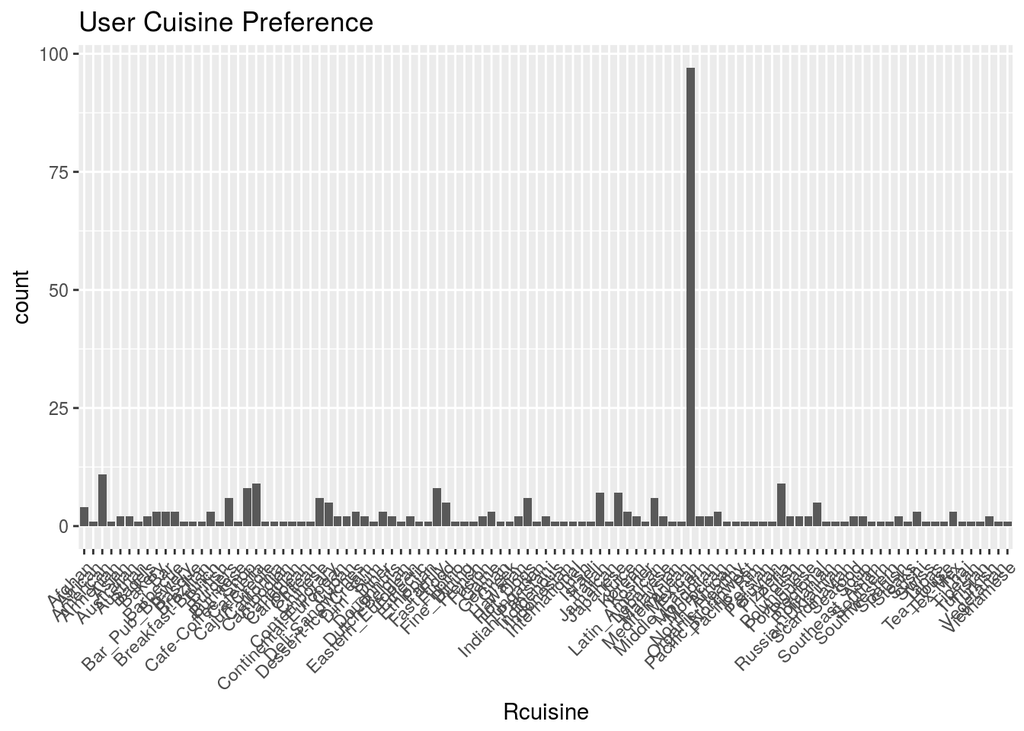

```r
ggplot( usercuisine , aes(Rcuisine))+geom_histogram( stat="count") +
  theme(axis.text.x = element_text(angle = 45, hjust = 1)) +
  labs(title="User Cuisine Preference")
```

#### 3.2.2.2 Overview

- It was clear that the most apreciated type of cuisine ismexican, and that was previous stated when the analysis of the geolocation was made and it was noticed that most of the restaurants where in fact located in Mexico.

### 3.2.3 userpayment.csv

#### 3.2.3.1 Main information

The dataset presented 177 instances over userID and Upayment attribute. it was possible to see what method of payment most of users preffer to use.

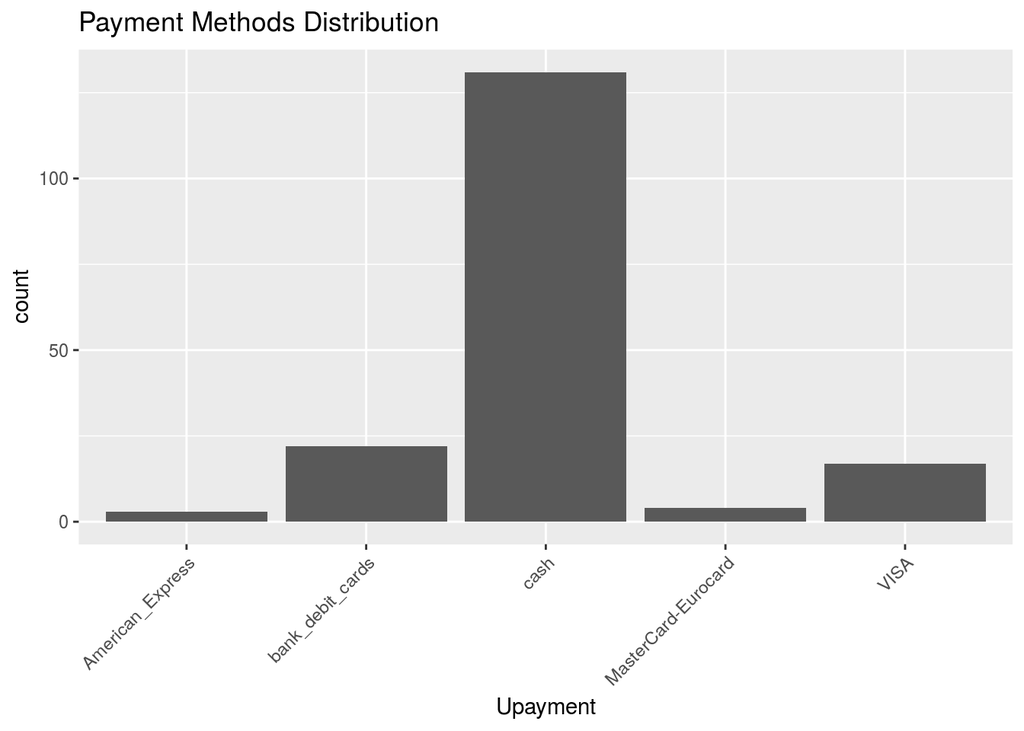

```r
ggplot( userpayment , aes(Upayment))+geom_histogram( stat="count") +
  theme(axis.text.x = element_text(angle = 45, hjust = 1)) +
  labs(title="Payment Methods Distribution")
```

#### 3.2.3.2 Overview

- Most of users preffer paying with cash, followed by bank debit cards and visa.

## 3.3 Ratings DATA

### 3.3.1 rating_final.csv

#### 3.3.1.1 Main information

When analyzing the rating_final.csv file, it was possible to see the rating given by wach user regarding the service, the food and an overall rating. It was also possible to observe the most common number of ratings given by user.

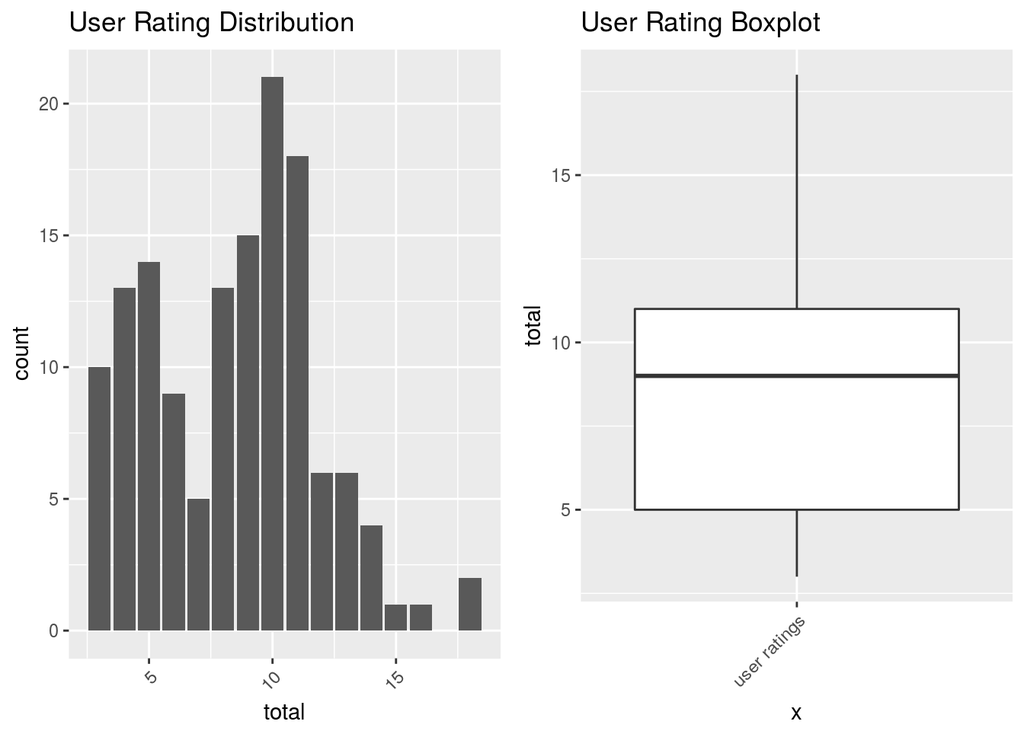

```r
g1 <- ggplot( user_ratings_count , aes(y=total, x="user ratings"))+geom_boxplot() +
  theme(axis.text.x = element_text(angle = 45, hjust = 1))+
  labs(title="User Rating Boxplot")

g2 <- ggplot( user_ratings_count , aes(total))+geom_histogram( stat="count") +
  theme(axis.text.x = element_text(angle = 45, hjust = 1)) +
  labs(title="User Rating Distribution")
```

### 3.3.2 User Profile

To make an embracing analysis, it was created a dendrogram (from Greek dendro “tree” and gramma “drawing”), that is a tree diagram, frequently used to illustrate the arrangement of the clusters produced by hierarchical clustering.

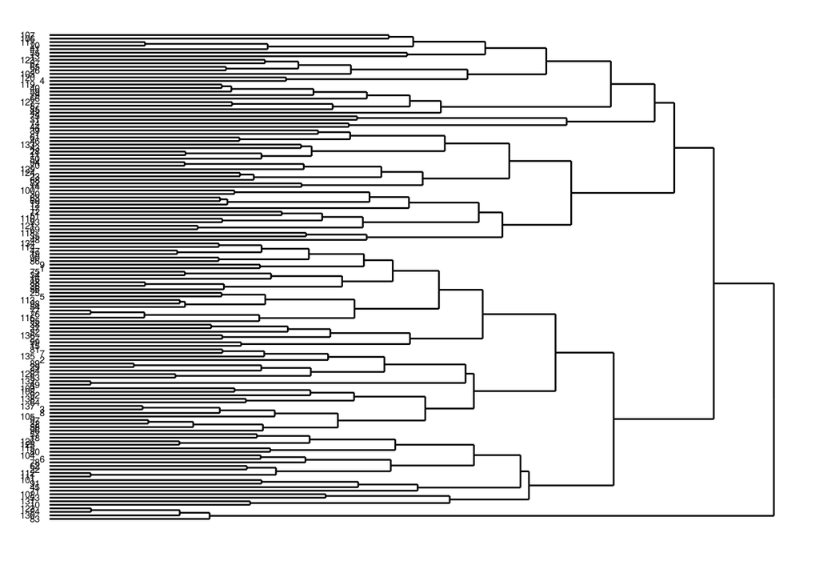

```r
um <- dist(userprofile)
uc <- hclust(um)
dhc <- as.dendrogram(uc)
ddata <- dendro_data(dhc)


ggplot(segment(ddata)) +
  geom_segment(aes(x = x, y = y, xend = xend, yend = yend)) +
  coord_flip() +
  theme_dendro() +
  geom_text(data = ddata$labels,
           aes(x = x, y = y, label = label),
           size = 2, hjust = 2,  position = position_dodge(width = 1))
```

### 3.3.3 Identifying similar users by profile

It was created a function that can define, comparing the profiles, which are the similar users related to a chosen one and it was tested to give the six similar users of user “U1044”. If we would not use the “recommender lab” package, we could use this function to identify simmilar users and create recommendations.

```r
similar_users_by_profile <- function(uID,n){
  ui <- rownames(userprofile[userprofile$userID == uID ,])
  um <- as.matrix(dist(userprofile))
  user_index <- tail(head(order(um[ui,]),n+1),-1)
  as.array(userprofile$userID[user_index])
}
```

```r
similar_users_by_profile('U1044',6)
```

```
## [1] U1074 U1093 U1121 U1069 U1078 U1110
## 138 Levels: U1001 U1002 U1003 U1004 U1005 U1006 U1007 U1008 U1009 ... U1138
```

### 3.3.4 Simmilar users by user preferences ( cuisines )

It was created a cluster that can define, comparing the cusine preferences, which are the similar users.

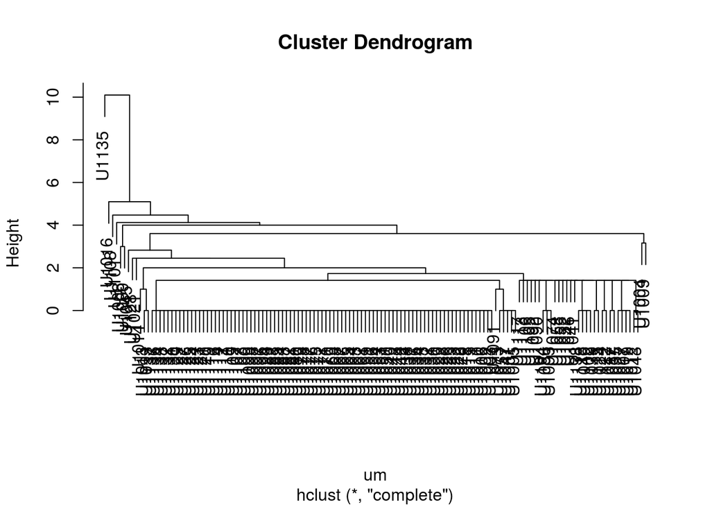

```r
user_cuisine_prefs <- table(usercuisine$userID,usercuisine$Rcuisine)

um <- dist(user_cuisine_prefs)
uc <- hclust(um)

plot(uc)
```

# 4 User Recommendation

After presenting an overview of the data set, we will start to experiment different recommendation models and evaluate the results. The aim is to Use binary and non-binary information on the users’ rating of restaurants to learn recommender systems and then recommend top N restaurants for a given user by: - Collaborative Filtering; - Popularity; - Association Rules;

## 4.1 Ratings Decisions

The group discussed on different ways we could format the ratings dataset as there are 3 types os ratings. These are the proposet data transformation for model creation:

- Create a model based on the sumation of the 3 types of ratings (rating + food_rating + service_rating):

```r
userRat_OP1 <- userRat %>%
                 mutate(final_rating = rating + food_rating + service_rating ) %>%
                 select(userID, placeID, final_rating)
```

- Create a model for each of the ratings and join the results ( as seen in CF Model)
- Create different combinations of the ratings ( as seen in Popular Recommneder Model)

## 4.2 Collaborative Filtering

In a general sense, collaborative filtering is the process of filtering for information or patterns using techniques involving collaboration among multiple agents, viewpoints and data sources.

### 4.2.1 Preparing the data set “rating_final.csv”

Here we have a few choices to reduce the three ratings into one: - OPTION 1 - we can create the model combining all ratings in one ( as descibed above ). - OPTION 2 - we can create 3 models, one for each rating and then try to combine the results ( as descibed above ).

### 4.2.2 Option 1

The model creation

```r
## creates the model
rmat_OP1 <- as(userRat_OP1, "realRatingMatrix")
model_OP1 <- Recommender(rmat_OP1, "UBCF", parameter = list(nn = 10, method = "cosine",normalize = NULL))


##recomending function
  recomment_place <- function(uID, n){
    p <- predict(model_OP1, rmat_OP1[uID,], n = n)
    #print( paste("RECOMENDER OPTION 1 - USER: ", uID) )
    as(p, "list")
}
```

### 4.2.3 Option 2

Three diffent models creation

```r
# Model for Rating
userRat_OP2_rating <- userRat %>% select(userID, placeID, rating)
rmat_OP2_1 <- as(userRat_OP2_rating, "realRatingMatrix")
model_OP2_1 <- Recommender(rmat_OP2_1, "UBCF", parameter = list(nn = 10, method = "cosine",normalize = NULL))

# Model for Service Rating
userRat_OP2_service_rating <- userRat %>% select(userID, placeID, service_rating)
rmat_OP2_2 <- as(userRat_OP2_service_rating, "realRatingMatrix")
model_OP2_2 <- Recommender(rmat_OP2_2, "UBCF", parameter = list(nn = 10, method = "cosine",normalize = NULL))

# Model for Food Rating
userRat_OP2_food_rating <- userRat %>% select(userID, placeID, food_rating)
rmat_OP2_3 <- as(userRat_OP2_food_rating, "realRatingMatrix")
model_OP2_3 <- Recommender(rmat_OP2_3, "UBCF", parameter = list(nn = 10, method = "cosine",normalize = NULL))

models_and_matrix <- list(c(model_OP2_1,rmat_OP2_1),c(model_OP2_2,rmat_OP2_2),c(model_OP2_3,rmat_OP2_3))
```

After transforming the data to be better used, the recomender function was implemented and a model of recommendation was created.

```r
# Recommendation Function
recomment_place_op2 <- function(model,uID, n,rm){
  p <- predict(model, rm[uID,], type="ratings")
  t <-as(p, "list")
  return(t)
  }

# Recommendation Agregate Function
recomment_place_op2_final <-function(uID,n){

    total <- as.data.frame(c("")) #EMPTY DF
    i <- 0

    for(mm in models_and_matrix){
        m <-mm[[1]]
        rm <- mm[[2]]
        np <- as.data.frame(recomment_place_op2(m,uID,5,rm))
        colnames(np) <- c(paste("model_",i,sep = ""))
        total <- cbind(total,np)
        i <- i +1
    }

    #Recomending

    final <-  total %>%
              mutate(models_rating = model_0 + model_1 + model_2 ) %>%
              rownames_to_column() %>%  select(rowname,models_rating) %>%
              arrange(desc(models_rating))
    #print( paste("RECOMENDER OPTION 2 - USER: ", uID) )
    return(head(final$rowname,n))

}
```

```r
recomment_place('U1137', 5)
```

```
## $U1137
## [1] "135032" "135057" "135076" "135052" "135060"
```

```r
recomment_place('U1138', 5)
```

```
## $U1138
## [1] "135075" "135026" "135079" "135085" "132951"
```

```r
recomment_place_op2_final('U1137', 5)
```

```
## [1] "135032" "135052" "135060" "132954" "135028"
```

```r
recomment_place_op2_final('U1138', 5)
```

```
## [1] "135075" "135026" "135079" "135085" "132951"
```

## 4.3 Popular

As the Popular Recommendation dosn’t take into account the user, but the number of ratings or the highest ratings, we tryed a mannual approach in order to compare to the “recommenderlab” package.

```r
total_user <- length(unique(userRat$userID))

teste <- userRat %>%  group_by(placeID) %>%
  dplyr::summarise (count_ratings_rest = n(),
                    mean_rat = mean(rating),
                    median_rat = mean(rating),
                    norm_rat = mean(rating)* (n()/total_user),
                    norm_food = mean(food_rating)* (n()/total_user),
                    norm_serv = mean(service_rating)* (n()/total_user),
                    total_median = mean(service_rating+rating+food_rating),
                    total_sum_norm = norm_rat + norm_food +norm_serv,
                    total_sum_mean = mean(rating) + mean(food_rating) + mean(service_rating),
                    total_sum_med = median(rating) + median(food_rating) + median(service_rating))
```

A few metrics were created in order to better classify the restaurants. The summation of the three ratings mean and median, a summation of a normalized mean witch takes into account the total number of ratings on the dataset, and jaust the mean and median of the rating variable. Later we intend to compare these approachs with the Popular method on the “recommender lab” package.

Here is the function we can use to find the top N restaurants based on these differen metrics.

```r
top_restaurants <- function(x){

  print(paste("Top",x, "restaurants"))

  print("Total Normalized")
  print(as(head(arrange(teste,desc(total_sum_norm)), n = x) %>% select(placeID),"list")[[1]])

  print("Total Sum of Mean")
  print(as(head(arrange(teste,desc(total_sum_mean)), n = x)%>% select(placeID),"list")[[1]])

  print("Total Sum of Median")
  print(as(head(arrange(teste,desc(total_sum_med)), n = x)%>% select(placeID), "list")[[1]])

  print("Sum of the ratings Median")
  print(as(head(arrange(teste,desc(total_median)), n = x)%>% select(placeID), "list")[[1]])

  print("Ratings Mean")
  print(as(head(arrange(teste,desc(mean_rat)), n = x)%>% select(placeID), "list")[[1]])

  print("Ratings Median")
  print(as(head(arrange(teste,desc(median_rat)), n = x)%>% select(placeID), "list")[[1]])

  #"Top Restaurants by Total Normalized, Total Mean, Total Median, Median of sum of ratings,  Ratings Mean and Ratings Median")

}

top_restaurants(8)
```

```
## [1] "Top 8 restaurants"
## [1] "Total Normalized"
## [1] 135085 132825 135032 135052 135038 132862 135060 132834
## [1] "Total Sum of Mean"
## [1] 134986 132955 135034 135013 132755 135074 132922 135055
## [1] "Total Sum of Median"
## [1] 132755 132862 132955 132958 134986 134999 135001 135013
## [1] "Sum of the ratings Median"
## [1] 134986 132955 135034 135013 132755 135074 132922 135055
## [1] "Ratings Mean"
## [1] 132955 134986 135034 132922 132755 134976 135013 135074
## [1] "Ratings Median"
## [1] 132955 134986 135034 132922 132755 134976 135013 135074
```

## 4.4 Popularity (Using Recommender Lab Package)

It was chosen to combine all ratings in one to evaluate the ratings and recommend the restaurants. After that, it was created the model.

```r
## creating the rating matrix
mr <- as(userRat_OP1, "realRatingMatrix")
```

### 4.4.1 Normalizing the Rating and Visualizing It

After applying the normalize function it was possible to plot the original rating distribution and the normalized one.

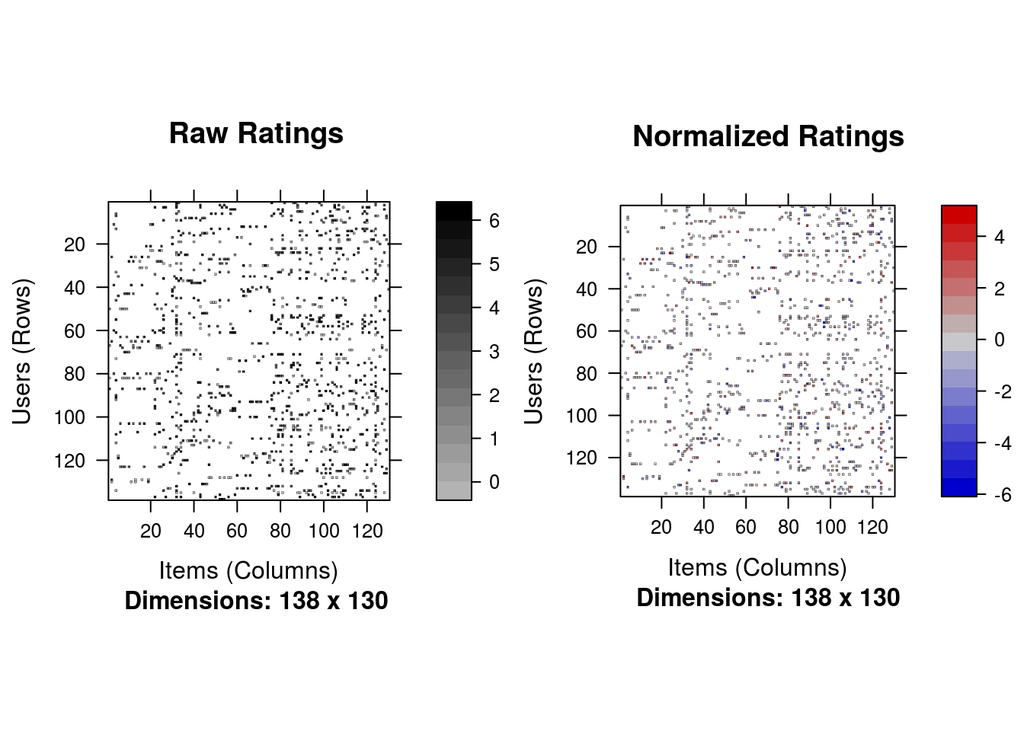

```r
#An important operation for rating matrices is to normalize the entries to, e.g.,
#centering to remove rating bias by subtracting the row mean from all ratings in the row.

r_m <- normalize(mr)

g1 <- image(mr, main = "Raw Ratings")
g2 <- image(r_m, main = "Normalized Ratings")
```

### 4.4.2 Creating a Recommendation Method: Popular

The recommender of type ‘POPULAR’ for ‘realRatingMatrix’ that was used here learned using the first 100 users.The model can be obtained from a recommender using getModel().

The testing was made for users “U1137” and “U1138”.

We create a recommender which generates recommendations solely on the popularity of items:

```r
tr <- Recommender(mr[1:100], method = "POPULAR")
getModel(tr)$topN
```

```
## Recommendations as 'topNList' with n = 130 for 1 users.
```

Recommendations are generated by predict() and the result contains two ordered top-5 recommendation lists, one for each user. The recommended items can be inspected as a list.

```r
recom <- predict(tr, mr[137:138], n=5)
as(recom, "list")
```

```
## $U1137
## [1] "134986" "132768" "135052" "135025" "132875"
##
## $U1138
## [1] "134986" "135085" "132768" "135052" "135025"
```

As oposed as previously though, the POPULAR method takes into account the user. because, if not, the recommendations would be equal for all users.

Since the top-N lists are ordered, we can extract sublists, in this case, of the best items in the top-5. For example, we can get the best 3 recommendations for each list using bestN().

```r
recom3 <- bestN(recom, n = 3)
as(recom3, "list")
```

```
## $U1137
## [1] "134986" "132768" "135052"
##
## $U1138
## [1] "134986" "135085" "132768"
```

### 4.4.3 Predicting the Rating

Another approach when using the recommender lab package is to use The following metod, that could predict the rating that would be given by a user for a restaurant which wasn’t rated by him before. The testing was made for users “U1137” and “U1138”.

```r
recom5 <- predict(tr, mr[137:138], type="ratings")
as(recom5, "matrix")[,1:10]
```

```
##         132560   132561   132564   132572   132583   132584   132594
## U1137 5.244048 5.271429 5.342262 5.065284 4.454762 6.246032 5.983631
## U1138 4.672619 4.700000 4.770833 4.493855 3.883333 5.674603 5.412202
##         132608   132609   132613
## U1137 5.969524 4.969524 5.819048
## U1138 5.398095 4.398095 5.247619
```

### 4.4.4 The Evaluatin of Recommender Algorithms

```r
e <- evaluationScheme(mr[1:100], method="split", train=0.9, given=-1, goodRating=5)
```

```r
r1 <- Recommender(getData(e, "train"), "UBCF")
r2 <- Recommender(getData(e, "train"), "IBCF")
r3 <- Recommender(getData(e, "train"), "POPULAR")
```

```r
p1 <- predict(r1, getData(e, "known"), type="ratings")
p2 <- predict(r2, getData(e, "known"), type="ratings")
p3 <- predict(r3, getData(e, "known"), type="ratings")
```

Finally, we can calculate the error between the prediction and the unknown part of the test data.

```r
error <- rbind(UBCF = calcPredictionAccuracy(p1, getData(e, "unknown")),IBCF = calcPredictionAccuracy(p2, getData(e, "unknown")), popular = calcPredictionAccuracy(p3, getData(e, "unknown")))
error
```

```
##             RMSE      MSE      MAE
## UBCF    2.144318 4.598098 2.008564
## IBCF    1.540061 2.371787 1.364394
## popular 1.878931 3.530384 1.664460
```

The result is an object of class EvaluationResult which contains several confusion matrices. getConfusionMatrix() will return the confusion matrices for the 5 runs (we used 5-fold cross evaluation) as a list. In the following we look at the first element of the list which represents the first of the 5 runs.

```r
scheme <- evaluationScheme(mr[1:100], method="cross", k=5, given=-1, goodRating=5)
results <- evaluate(scheme, method="POPULAR", type = "topNList",n=c(1,2,5))
```

```
## POPULAR run fold/sample [model time/prediction time]
##   1  [0.004sec/0.04sec]
##   2  [0.004sec/0.028sec]
##   3  [0sec/0.028sec]
##   4  [0sec/0.032sec]
##   5  [0.004sec/0.028sec]
```

```r
getConfusionMatrix(results)[[1]]
```

```
##   TP FP   FN     TN precision recall TPR        FPR
## 1  0  1 0.35 129.65         0      0   0 0.00765414
## 2  0  2 0.35 128.65         0      0   0 0.01530828
## 5  0  5 0.35 125.65         0      0   0 0.03827070
```

### 4.4.5 Comparing Top-N Recommendations

The comparison of several recommender algorithms is one of the main functions of recommenderlab. For comparison also evaluate() is used. It was also plotted a barplot that shows the root mean square error, the mean square error and the mean average error.

```r
scheme <- evaluationScheme(mr[1:100], method="split", train = .9, k=5, given=3, goodRating=5)

algorithms <- list(
   "random items" = list(name="RANDOM", param=NULL),
   "popular items" = list(name="POPULAR", param=NULL),
   "user-based CF" = list(name="UBCF", param=list(nn=5)),
   "item-based CF" = list(name="IBCF", param=list(k=5))
)

## run algorithms
results <- evaluate(scheme, algorithms, type = "topNList", n=c(1, 2, 5))
```

```
## RANDOM run fold/sample [model time/prediction time]
##   1  [0sec/0.008sec]
##   2  [0.028sec/0.008sec]
##   3  [0sec/0.008sec]
##   4  [0sec/0.008sec]
##   5  [0sec/0.008sec]
## POPULAR run fold/sample [model time/prediction time]
##   1  [0.004sec/0.016sec]
##   2  [0.004sec/0.02sec]
##   3  [0.004sec/0.016sec]
##   4  [0.004sec/0.012sec]
##   5  [0sec/0.016sec]
## UBCF run fold/sample [model time/prediction time]
##   1  [0.004sec/0.008sec]
##   2  [0sec/0.016sec]
##   3  [0sec/0.012sec]
##   4  [0sec/0.012sec]
##   5  [0.004sec/0.012sec]
## IBCF run fold/sample [model time/prediction time]
##   1  [0.036sec/0.14sec]
##   2  [0.012sec/0.004sec]
##   3  [0.012sec/0.008sec]
##   4  [0.012sec/0.008sec]
##   5  [0.024sec/0.004sec]
```

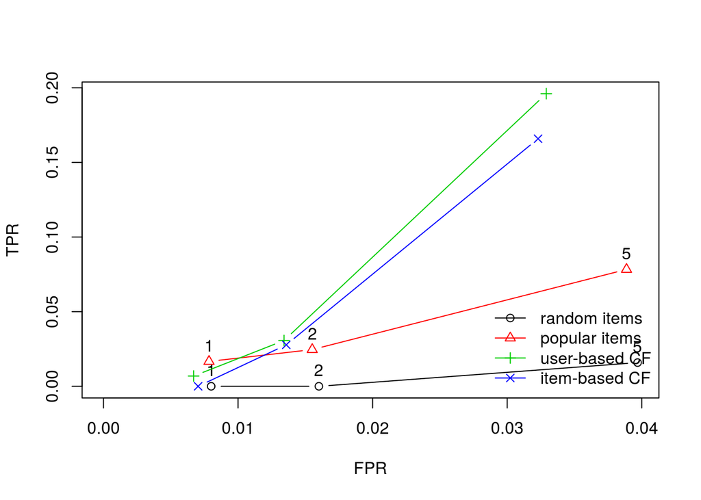

```r
#plots the comparative graph
plot(results, annotate=c(1,2,5), legend="bottomright")
```

```r
#Plotting the results shows a barplot with the root mean square error, the mean square error and the mean average error
results2 <- evaluate(scheme, algorithms, type = "ratings")
```

```
## RANDOM run fold/sample [model time/prediction time]
##   1  [0sec/0.004sec]
##   2  [0.004sec/0sec]
##   3  [0sec/0.004sec]
##   4  [0sec/0.004sec]
##   5  [0.004sec/0.004sec]
## POPULAR run fold/sample [model time/prediction time]
##   1  [0.004sec/0sec]
##   2  [0sec/0.004sec]
##   3  [0.004sec/0sec]
##   4  [0sec/0.004sec]
##   5  [0sec/0.004sec]
## UBCF run fold/sample [model time/prediction time]
##   1  [0.008sec/0.008sec]
##   2  [0sec/0.012sec]
##   3  [0.004sec/0.008sec]
##   4  [0sec/0.012sec]
##   5  [0sec/0.008sec]
## IBCF run fold/sample [model time/prediction time]
##   1  [0.016sec/0.004sec]
##   2  [0.012sec/0.008sec]
##   3  [0.012sec/0.008sec]
##   4  [0.02sec/0.004sec]
##   5  [0.016sec/0.004sec]
```

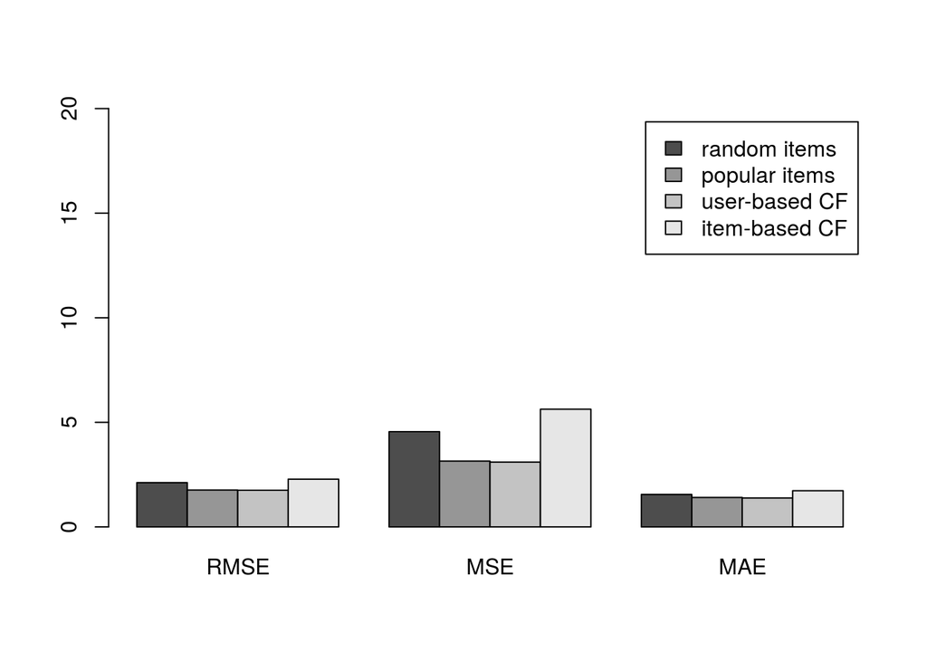

```r
plot(results2, ylim = c(0,20))
```

### 4.4.6 Using a Binary Data Set

```r
m_b <- as(userRat_OP1, "binaryRatingMatrix")

scheme_binary <- evaluationScheme(m_b[1:100], method="split", train = .9, k=5, given=-1)

results_binary <- evaluate(scheme_binary, algorithms, type = "topNList", n=c(1,2,5))
```

```
## RANDOM run fold/sample [model time/prediction time]
##   1  [0sec/0.008sec]
##   2  [0.012sec/0.004sec]
##   3  [0sec/0.008sec]
##   4  [0sec/0.004sec]
##   5  [0sec/0.004sec]
## POPULAR run fold/sample [model time/prediction time]
##   1  [0.004sec/0.028sec]
##   2  [0.012sec/0.024sec]
##   3  [0.004sec/0.024sec]
##   4  [0sec/0.024sec]
##   5  [0.004sec/0.024sec]
## UBCF run fold/sample [model time/prediction time]
##   1  [0sec/0.044sec]
##   2  [0.024sec/0.096sec]
##   3  [0sec/0.036sec]
##   4  [0sec/0.044sec]
##   5  [0sec/0.036sec]
## IBCF run fold/sample [model time/prediction time]
##   1  [0.012sec/0.008sec]
##   2  [0.04sec/0.004sec]
##   3  [0.012sec/0.004sec]
##   4  [0.008sec/0.008sec]
##   5  [0.016sec/0.008sec]
```

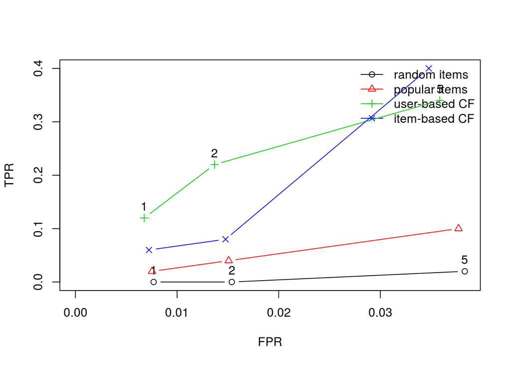

```r
plot(results_binary, annotate=c(1,3), legend="topright")
```

## 4.5 Association Rules

Association rules are used when identifying patterns in a “basket data”, with transactions that possibly consist of multiple items. In this case, the basket has the restaurants that were rated for each user. It aims to find rules that will predict the occurrence of an item, based on other items in “user’s shopping baskets”.

It was chosen to combine all ratings in one to evaluate the ratings and recommend the re#staurants.

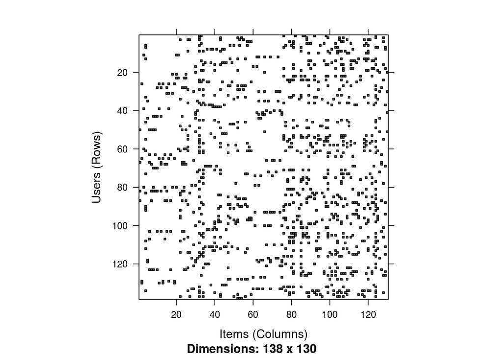

```r
mb <- as(userRat_OP1, "binaryRatingMatrix")
dat <- table(userRat_OP1$userID, userRat_OP1$placeID)
image(mb)
```